# Models for Network Diffusion and Social Influence

Leonie Mertes

Seminar: Analyse von Netzwerkdaten

Betreuer: Prof. Dr. Göran Kauermann

06.16.2026

## Agenda: Models for Network Diffusion

1. Flows
2. SIR model
3. Network topology effects
4. Simulation Models
5. Dynamic Networks
6. Social and behavioral diffusion
7. Treshold Models

## Agenda: Models for Social Influence

1. Network Theory
2. Causal Inference
3. Methodological Challenges
4. Research Strategies
5. Modeling effects of Network social influence
6. Instrumental Variable and Structural Equation Approaches
7. Stochastic Actor-Oriented Models (SAOMs)
8. Sensitivity Analysis

## Motivation

## Flows

## SIR model

## SIR model over time

## Network topology effects on diffusion

virulence definition - Connectivity - Efficiency - Volume

## Simulation models: test how network structure affects diffusion

## dynamic networks

## Social and behavioral diffusion

SIR diffusion model assumptions: - Individual Contagion - Stability of the contagion - Irrelevance of the contagion to the infector - Single-Source Adoption - Simple state change - Dyadic independence

## Resource Exchange and Social Capital

## Treshold Models Idea

- Public Goods
- Collective Action
- Complex Contagion

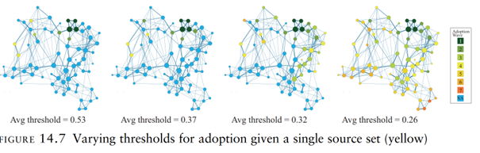

## Treshold Models

- Granovetters Modell: variierendes individuelles Level an akzeptieren Kosten
- Erweiterung: Lokale Nachbarn erfüllen Treshold
- Valentes model: individuelle Tresholds
- Centola and Macys: Art der Verbindung entscheidend

## Social Influence

## Causal Inference

## Methodological Challenges

## Research Strategies

- Labratory Experiments
- Field Experiments
- Natural Experiments

## Modeling effects of Network social influence

## Instrumental Variable and Structural Equation Approaches

## Stochastic Actor-Oriented Models (SAOMs)

## Sensitivity Analysis

- Ziel: Prädiktion nachgefragter Titel über 4 Wochen zur Nachbestellung von Exemplaren bei Engpässen
- Struktur: Transaktionsdaten auf Ereignisebene

  | AKKEY | EXEMPLARID | AUSLEIHART | ERFASSUNGSDATUM | GROSSGRUPPE | … |
  | --- | --- | --- | --- | --- | --- |
  | 001 | 01 | Ausleihe | 2025-10-02 | Belletristik | … |
  | 001 | 02 | Vormerkung | 2025-10-04 | Belletristik | … |
  | 002 | 01 | Rückgabe | 2025-10-02 | Sachliteratur | … |

- n = 16 172 321, mit 215 418 AKKEYs
- Filterung auf Großgruppe “Belletristik”: n = 2 409 873 für Modellierung

## Mathematische Formeln

$\mathrm{RMSE} = \sqrt{\mathrm{MSE}} = \sqrt{\frac{1}{m} \sum_{i=1}^{m} \left(y_i - \hat{y_i}\right)^2}$

## Solide Vorhersage der OOS-Rate

- **Szenario:** Vergleich der tatsächlichen Nachkäufe von Bestandstiteln (Aufstockung) mit den Top-Empfehlungen des Modells
- **Budget-Fixierung:** Simulation von 677 Exemplaren für beide Gruppen

Mittlere OOS-Rate in beiden Gruppen:

|  | Gesamter Bestand | Tatsächliche Nachkäufe | Modellempfehlungen |
| --- | --- | --- | --- |
| **Mittlere OOS-Rate** | 15.8 % | 56.2 % | 77.4 % |

- ausführliches Preprocessing für Modellierung nötig
- gute Prädiktion für kommende vier Wochen

Ausblick und Diskussion

- Prädiktion über längeren Zeithorizont
- Exaktere historische Bestandsdaten und Eventlogik
- Erweiterung auf weitere Genres